# WeRateDogs Tweets [Nov 2015 - Aug 2017] Report

We had a look at the tweets by @dogrates and derived some interesting insights about dogs.  
The total tweets we had were **2,167**  
We also took an interest in the tweets that had the highest(Top 25%) engagement i.e

- likes
- quotes
- retweets
- replies

We'll represent here some of the insights looking at both the total tweets and tweets from the top 25% in social media engagement

### 1. The Golden Retriever is the most common breed

Among the top quartile, the Chihuahua is more popular but the golden retriever follows closely behind

Dog Breeds

Dog Breeds in Top 25% Tweets

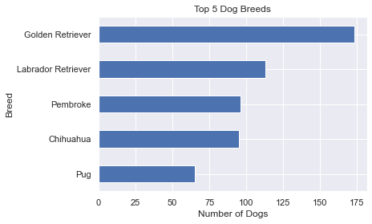

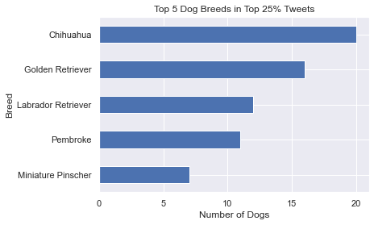

### 2. @dog_rates had a very active account manager in 2015.

The tweets per month in the two months of 2015 were unmatched for the next 20 months.  
The tweets have been fewer ever since.

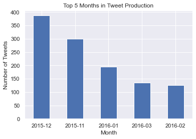

### 3. 2017 was the year for social media engagement.

Though the tweet count was lowest in 2017, the reach was wider.  
Most of the top tweets by social media engagement are from 2017

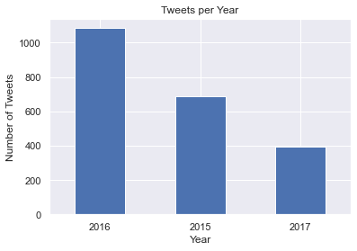

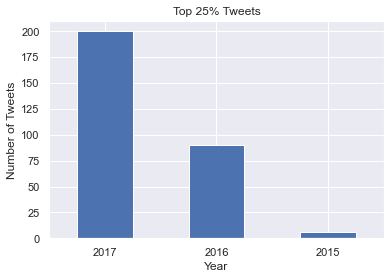

### 4. Dogs have very unique names

There were a total of **790** unique dog names from about **1105** tweets that had dog names.  
The maximum number of dogs that shared any particular name were 9.

### 5. Puppers seem to be the most sent in dogs

Of the **383** dogs whose stages were mentioned, puppers were the most common.

Dog Stages

Dog Stages in Top 25% Tweets

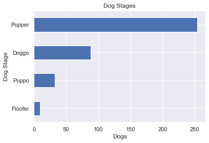

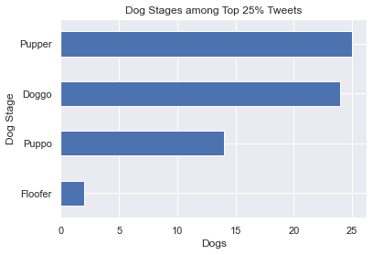

```python
%%html
<style>
table {float:left}
</style>
```